# Homework 1

Group A**: Abdalghani, Brand, Tasciotti, Fernández Santisteban

# Laboratory 1

### Exercise 1

- Write a function $\mathsf{binomial(x,n,p)}$ for the binomial distribution above, depending on parameters $x,n,p$ and test it with some prespecified values. Use the function $\mathsf{choose()}$ for the binomial coefficient.

**Solution**

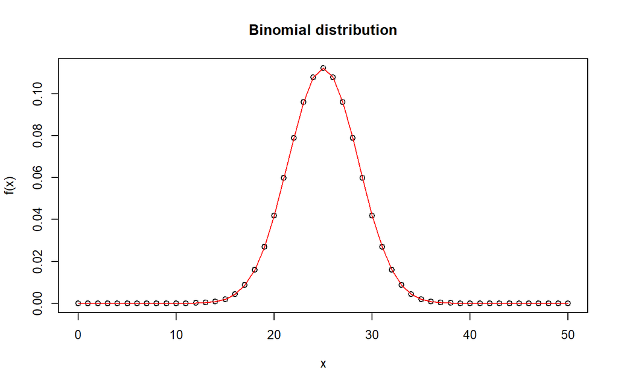

```r
binomial<-function(x,n,p)
{
  return(choose(n,x)*(p^x)*(1-p)^(n-x))
}
n <- 50
p <- 0.5
x <- seq(from=0, to=50, length.out = 51)
plot(x, binomial(x,n,p), xlab="x", ylab="f(x)", main="Binomial distribution")
lines(x, dbinom(x,n,p), col="red")
```

- Plot two binomials with n=20, and p=0.3,0.6 respectively.

**Solution**

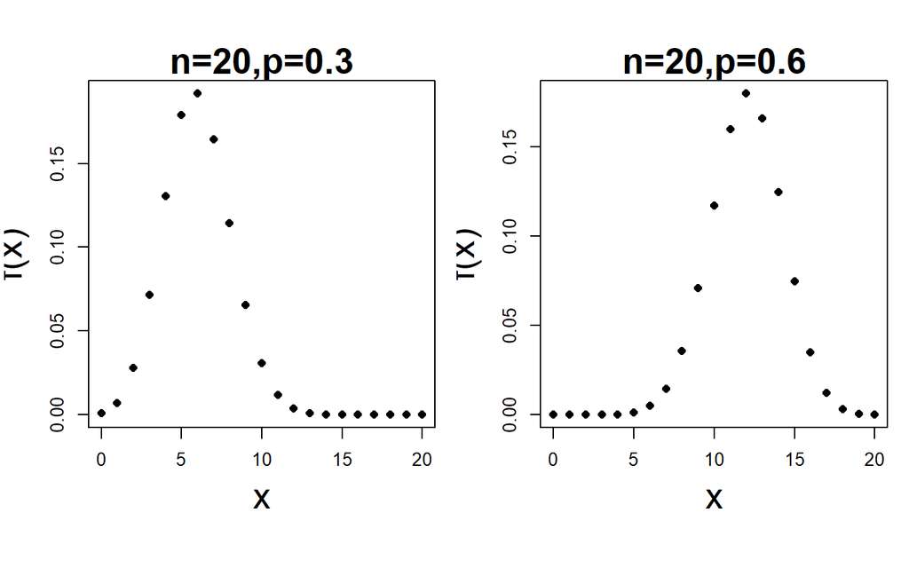

```r
par(mfrow=c(1,2),mar=c(5,4,2,1), oma=c(0,0.2,0.2,0), pty="s", pch = 16)
plot(0:20, binomial(0:20, 20, 0.3), xlab = "x", ylab = "f(x)", cex.lab=2, main="n=20,p=0.3", cex.main=2)
plot(0:20, binomial(0:20, 20, 0.6), xlab = "x", ylab = "f(x)", cex.lab=2, main="n=20,p=0.6", cex.main=2)
```

### Exercise 2

- Generate in $\mathsf{R}$ the same output, but using $\mathsf{rgeom()}$ for generating the random variables. *Hint*: generate $n$ times three geometric distribution $X_1,\ldots, X_3$ with $p=0.08$, store them in a matrix and compute then the sum $Y$.

**Solution**

In order to obtain the pdf of the sum of k Random Variables we need to apply the operation of convolution to them. In the discrete case we have
$$Z = X + Y \rightarrow p(Z=i) = \sum_{k \in \mathbb{X}, \mathbb{Y} } p(x=k)\cdot p(y=i-k)$$

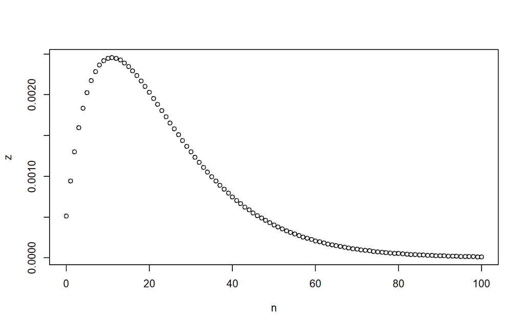

```r
n <- 0:100
x1 <- dgeom(n,0.08)
x2 <- dgeom(n,0.08)
z <- replicate(0,n)
z <-integer(length(n))

for( j in n){
  for( k in 0:j ){
    z[j+1] <- z[j+1] + (x1[k+1] * x2[j-k+1]) #Convolution of x1 and x2
  }
}

x3 <- z
for( j in n){
  for( k in 0:j ){
    z[j+1] <- x3[k+1] * x2[j-k+1]
  }
}

plot(n,z)
```

### Exercise 3

Show in $\mathsf{R}$, also graphically, that $\mbox{Gamma}(n/2, 1/2)$ coincides with a $\chi^{2}_{n}$.

- Find the 5% and the 95% quantiles of a $\mbox{Gamma}(3,3)$.

**Solution**

The density for a $\mbox{Gamma}(\alpha, \beta)$ is:
$$f(x; \alpha, \beta)= \frac{\beta^{\alpha} }{\Gamma(\alpha)}e^{-\beta x}x^{\alpha-1}, \ \ \alpha, \beta >0, \ x >0.$$
Thus, the density for a $\mbox{Gamma}\bigg(\frac{n}{2}, \frac{1}{2}\bigg)$ is:
$$f\bigg(x; \frac{n}{2}, \frac{1}{2}\bigg)= \frac{e^{-\frac{x}{2}}x^{\frac{n}{2}-1}}{\Gamma\bigg(\frac{n}{2}\bigg)2^{\frac{n}{2}}}$$

The density for a $\chi^{2}_{k}$ is:
$$f(x;k)=\frac{x^{\frac{k}{2}-1}e^{-\frac{x}{2}} }{\Gamma\bigg(\frac{k}{2}\bigg)2^{\frac{k}{2}}}, \ \ x >0.$$
Thus, the density for a $\chi^{2}_{n}$ is:
$$f(x;n)=\frac{x^{\frac{n}{2}-1}e^{-\frac{x}{2}} }{\Gamma\bigg(\frac{n}{2}\bigg)2^{\frac{n}{2}}}$$
Hence, we notice that $\mbox{Gamma}(n/2, 1/2)$ coincides with a $\chi^{2}_{n}$.

This result can be proved also graphically:

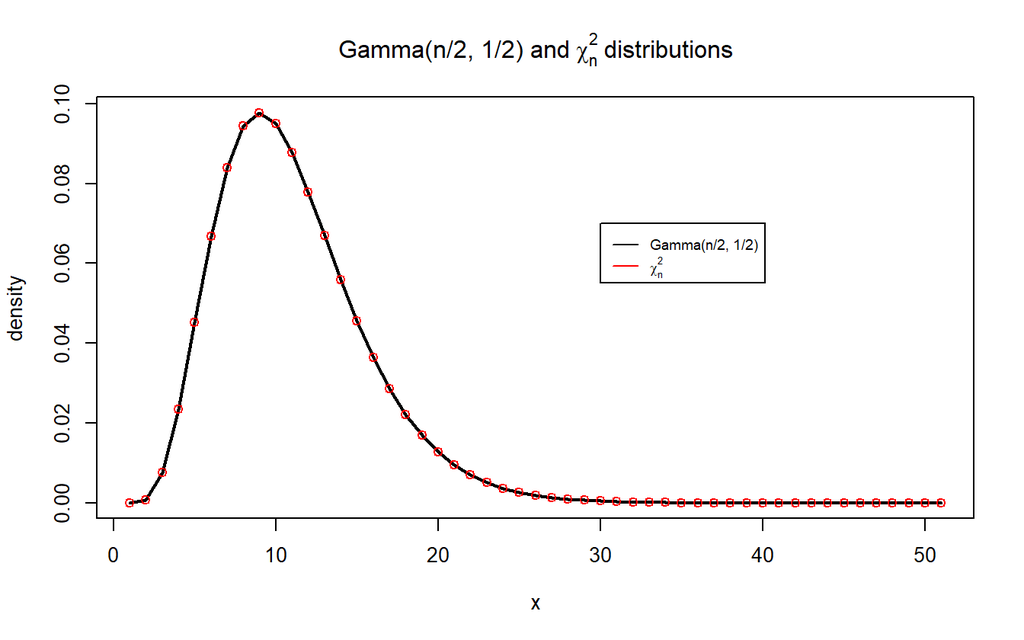

```r
n=10
plot(dgamma(0:50,shape=n/2,rate = 1/2), lwd=2,type="l",xlab="x",ylab = "density",main=bquote("Gamma(n/2, 1/2) and" ~ chi[n]^2 ~ "distributions"))
lines(dchisq(0:50, n),col='red',type = "p")
legend(30,0.07,legend=c("Gamma(n/2, 1/2)",expression(chi[n]^2)),col=c("black", "red"),lty=1, cex=0.7)
```

The $5\%$ and the $95\%$ quantiles of a $\mbox{Gamma}(3, 3)$ are given respectively by:

```r
shape=3
rate=3
qgamma(.05,shape,rate) # 5-th quantile
```

```
## [1] 0.2725638
```

```r
qgamma(.95,shape,rate) # 95-th quantile
```

```
## [1] 2.098598
```

### Exercise 4

Generate $n=1000$ values from a $\mbox{Beta}(5,2)$ and compute the sample mean and the sample variance.

**Solution**

In order to generate samples from a Beta distribution it is used the $\mathsf{rbeta(n, alpha, beta)}$, where $\mathsf{n}$ is the number of samples and $\mathsf{alpha}$ and $\mathsf{beta}$ are the first and the second parameter respectively from the Beta distribution.

```r
#Sampling procedure
n<-1000; alpha<-5; beta<-2
samples <- 1:n
samples<-rbeta(n, alpha, beta)

#Statistics
mean(samples)
```

```
## [1] 0.7192747
```

```r
var(samples)
```

```
## [1] 0.02570511
```

### Exercise 5

Analogously, show with a simple $\mathsf{R}$ function that a negative binomial distribution may be seen as a mixture between a Poisson and a Gamma. In symbols: $X|Y \sim \mathcal{P}(Y)$, $Y \sim \mbox{Gamma}(\alpha, \beta)$, then $X \sim \ldots$.

**Solution**

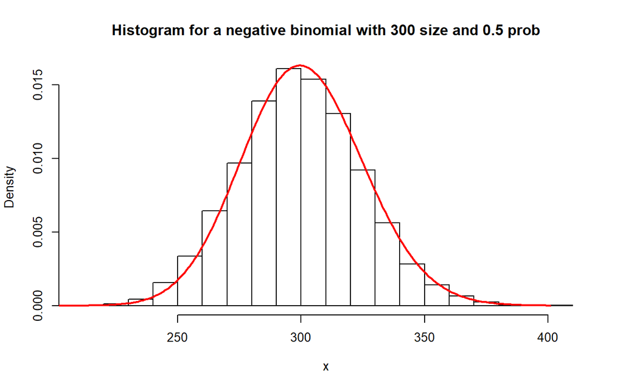

```r
nbi_mixture<-function(alpha,n,beta){
  Z=rgamma(n,alpha,beta)
  X=rpois(n,Z)
  return(X)
}
alpha<-300
beta<-1
hist(nbi_mixture(alpha,10000,beta),probability = TRUE, breaks = 20,
     main = paste("Histogram for a negative binomial with",alpha,"size and",1/(beta+1),"prob"),xlab = "x")
lines(dnbinom(0:400,alpha,1/(beta+1)),col="red",lwd=2)
```

From this plot it is possible to notice that the mixture between $X|Y \sim \mathcal{P}(Y)$ and $Y \sim \mathcal{Gamma}(\alpha,\beta)$ leads to $X \sim {\cal B}_i\bigg(\alpha,\frac{1}{\beta+1}\bigg).$

We have choosen $\alpha=300$ and $\beta=1$ for the $\mathcal{Gamma}$ distribution and, accordingly, we have obtained a $\mathcal{NegativeBinomial}$ distribution with mean $\mu=\frac{\alpha p}{1-p}=300$, where $p=\frac{1}{\beta+1}.$

### Exercise 6

Instead of using the built-in function $\mathsf{ecdf()}$, write your own $\mathsf{R}$ function for the empirical cumulative distribution function and reproduce the two plots above.

**Solution**

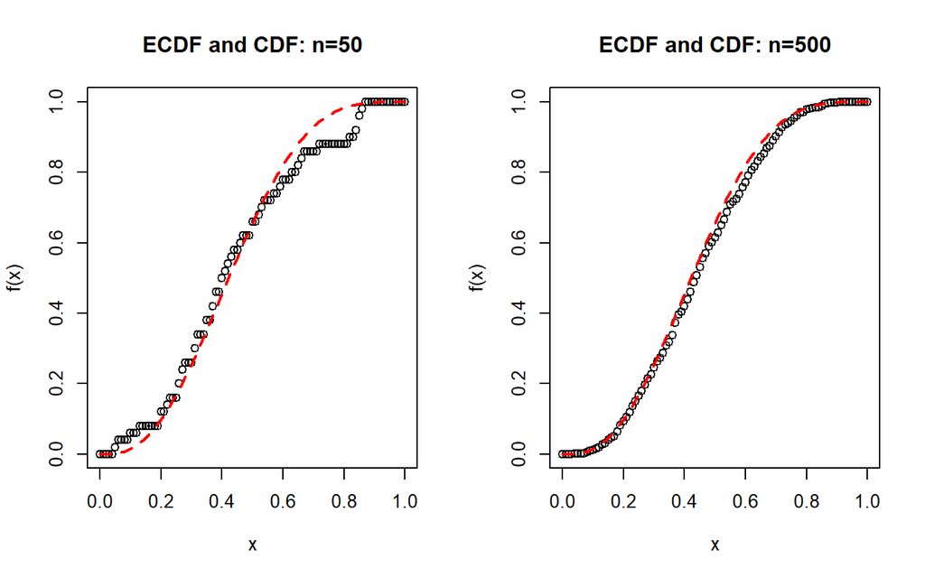

```r
ecdf_ <- function(dist,xt){
  result = vector(length = length(xt))
  for(i in 1:length(xt)){
    result[i]=length(dist[dist<=xt[i]])/length(dist)
  }
  return(result)
}

set.seed(2)
par(mfrow=c(1,2))
xt<-seq(from=0, to=1, by=0.01)

n1<-50
y1<-rbeta(n1, 3,4)
plot(xt, ecdf_(y1,xt),xlab = "x", ylab = "f(x)", main="ECDF and CDF: n=50")
lines(xt, pbeta(xt,3,4), col=2, lty=2, lwd=2)

n2<-500
y2<-rbeta(n2, 3,4)
plot(xt, ecdf_(y2,xt),xlab = "x", ylab = "f(x)", main="ECDF and CDF: n=500")
lines(xt, pbeta(xt,3,4), col=2, lty=2, lwd=2)
```

### Exercise 7

Compare in $\mathsf{R}$ the assumption of normality for these samples:

- $y_1, \ldots, y_{100} \sim t_{\nu},$ with $\nu=5,20, 100$. What does it happens when the number of degrees of freedom $\nu$ increases?
- $y_1, \ldots, y_{100} \sim \mbox{Cauchy}(0,1)$. Do you note something weird for the extremes quantiles?

**Solution**

#### Sample from t distrib

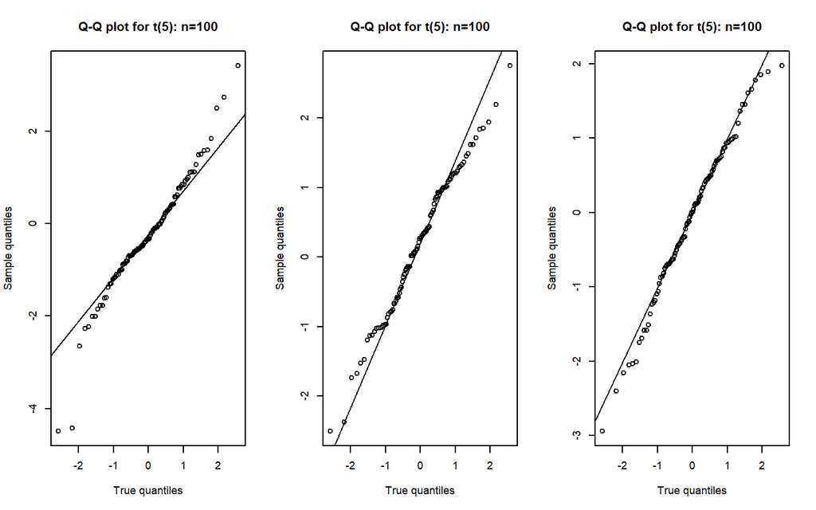

```r
n <- 100
y5 <- rt(n,5) #y is a vector of samples distributed as a t with degree of freedom 5
y20 <- rt(n,20)
y100 <- rt(n,100)
par(mfrow=c(1,3))
qqplot(qnorm(ppoints(n)),y5, #Comparison with a normal distrib
       xlab="True quantiles", ylab="Sample quantiles",
       main = "Q-Q plot for t(5): n=100")
qqline(y5)
qqplot(qnorm(ppoints(n)),y20, #Comparison with a normal distrib
       xlab="True quantiles", ylab="Sample quantiles",
       main = "Q-Q plot for t(5): n=100")
qqline(y20)
qqplot(qnorm(ppoints(n)),y100, #Comparison with a normal distrib
       xlab="True quantiles", ylab="Sample quantiles",
       main = "Q-Q plot for t(5): n=100")
qqline(y100)
```

We can see from the plot that as the number of degrees of freedom augments the distribution tends to a Normal distribution on the tails of the samples.

#### Sample from Cauchy distribution

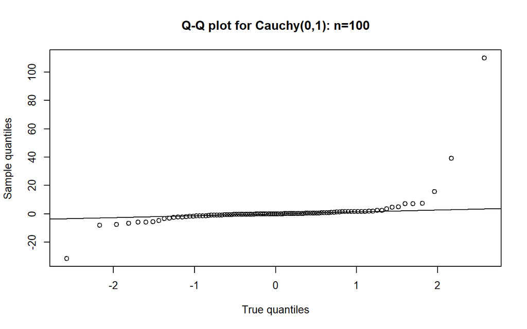

```r
y <- rcauchy(n)
qqplot(qnorm(ppoints(n)),y, #Comparison with a normal distrib
       xlab="True quantiles", ylab="Sample quantiles",
       main = "Q-Q plot for Cauchy(0,1): n=100")
qqline(y)
```

The extreme quantiles are definitely not aligned with our normality assumption.

### Exercise 8

Write a general $\mathsf{R}$ function for checking the validity of the central limit theorem. *Hint*. The function will consist of two parameters: clt_function <- function($\mathsf{n}$, $\mathsf{distr}$), where the first one is the sampe size and the second one is the kind of distribution from which you generate. Use plots for visualizing the results.

**Solution**

Central limit theorem implies that the mean of means over n populations follows a $\cal N(\left< \bar{\mu} \right>, \sigma^2(\bar{\mu}))$. First of all it has been computed a list of samples. Then it is computed the mean of each sample and finally it is plotted the histogram and its associated c.l.t. Normal distribution.

```r
ctl_function <- function(n, distr){
  #sample of means (over populations of 5 samples)
  mu_samples <- 1:n
  for (i in 1:n){
    sample <- distr(5)
    mu_samples[i] <- mean(sample)
  }

  #sample statistics
  mu <- mean(mu_samples)
  sigma2 <- var(mu_samples)

  #plot, histogram and normal dist.
  hist(mu_samples, breaks=100, probability=TRUE)
  curve(dnorm(x, mu, sqrt(sigma2)), xlim=c(min(mu_samples),max(mu_samples)),
        xlab="x", ylab="f(x)",
        main=paste("n=", n), cex.main=1.5, add=TRUE, col="red")
}
```

1.Example with Gamma distribution and n=10000:

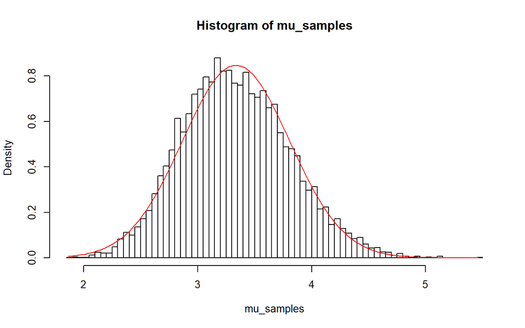

```r
rdist <- function(n) rgamma(n, 10 ,rate=3)
ctl_function(10000, rdist)
```

2.Example with Gamma distribution and n=1000000:

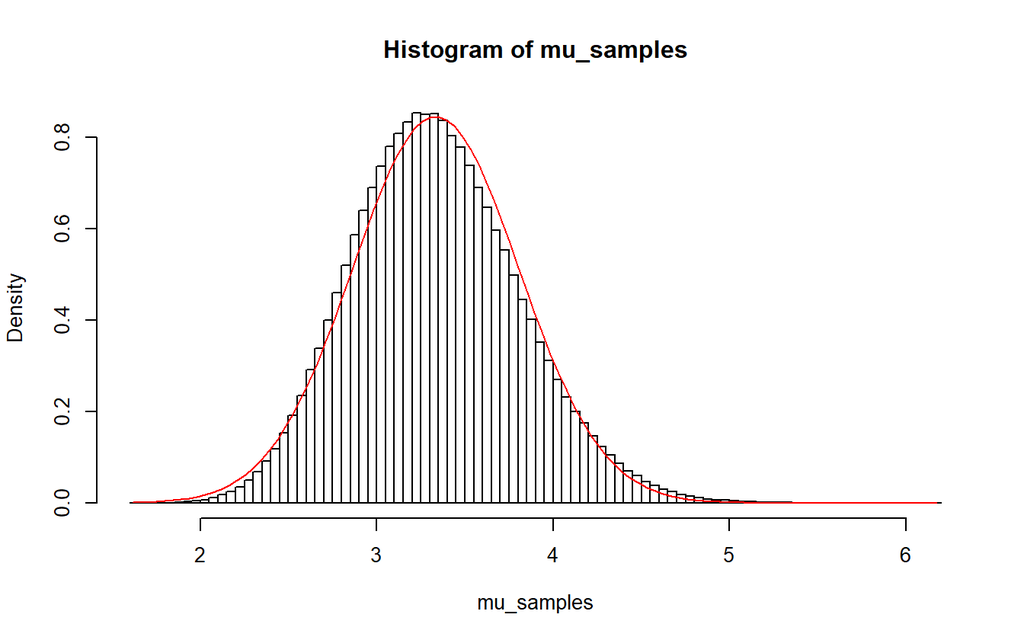

```r
rdist <- function(n) rgamma(n, 10 ,rate=3)
ctl_function(1000000, rdist)
```

# Data Analysis and Graphics Using R

### Exercise 4

For the data frame $\mathsf{ais}$ (DAAS package)

1. Use the function $\mathsf{str()}$ to get information on each of the columns. Determine whether any of the columns hold missing values.

**Solution:**

```r
library(DAAG)
ais -> df;

#information of each column and amount of missing information
str(df)
```

```
## 'data.frame':    202 obs. of  13 variables:
##  $ rcc   : num  3.96 4.41 4.14 4.11 4.45 4.1 4.31 4.42 4.3 4.51 ...
##  $ wcc   : num  7.5 8.3 5 5.3 6.8 4.4 5.3 5.7 8.9 4.4 ...
##  $ hc    : num  37.5 38.2 36.4 37.3 41.5 37.4 39.6 39.9 41.1 41.6 ...
##  $ hg    : num  12.3 12.7 11.6 12.6 14 12.5 12.8 13.2 13.5 12.7 ...
##  $ ferr  : num  60 68 21 69 29 42 73 44 41 44 ...
##  $ bmi   : num  20.6 20.7 21.9 21.9 19 ...
##  $ ssf   : num  109.1 102.8 104.6 126.4 80.3 ...
##  $ pcBfat: num  19.8 21.3 19.9 23.7 17.6 ...
##  $ lbm   : num  63.3 58.5 55.4 57.2 53.2 ...
##  $ ht    : num  196 190 178 185 185 ...
##  $ wt    : num  78.9 74.4 69.1 74.9 64.6 63.7 75.2 62.3 66.5 62.9 ...
##  $ sex   : Factor w/ 2 levels "f","m": 1 1 1 1 1 1 1 1 1 1 ...
##  $ sport : Factor w/ 10 levels "B_Ball","Field",..: 1 1 1 1 1 1 1 1 1 1 ...
```

```r
ok <- complete.cases(df[, 1:13]);
sum(!ok) #no missing values
```

```
## [1] 0
```

2. Make a table that shows the numbers of males and females for each different sport. In which sports is there a large inbalance (e.g., by a factor of more than 2:1) in the numbers of the two sexs?

**Solution:**

```r
#Making a table with the number of males and females for each sport
  #make the table
df_sub_sport <- df[,12:13]
df_sport <- t(table(df_sub_sport))
df_sport <- data.frame(df_sport)

  #get data on each sex and avoid repeated sports
df_sport_m <- subset(df_sport, sex=="m")
df_sport_f <- subset(df_sport, sex=="f")
df_sport <- df_sport[1:(length(df_sport$sport)/2),]

  #joining all the data
df_sport$male = df_sport_m$Freq
df_sport$female = df_sport_f$Freq

  #males and females
df_sport <- data.frame(sport=df_sport$sport, male=df_sport$male, female=df_sport$female)
df_sport
```

```
##      sport male female
## 1   B_Ball   12     13
## 2    Field   12      7
## 3      Gym    0      4
## 4  Netball    0     23
## 5      Row   15     22
## 6     Swim   13      9
## 7   T_400m   18     11
## 8  T_Sprnt   11      4
## 9   Tennis    4      7
## 10  W_Polo   17      0
```

```r
#sports unbalanced by a factor 1:k
k<-2;

df_sport$balance <- df_sport$male/df_sport$female

unb_df <- subset(df_sport, balance>k | balance<1/k)

unb_sports <- unb_df$sport;
unb_sports
```

```
## [1] Gym     Netball T_Sprnt W_Polo
## 10 Levels: B_Ball Field Gym Netball Row Swim T_400m T_Sprnt ... W_Polo
```

### Exercise 6

Create a data frame called $\mathsf{Manitoba.lakes}$ that contains the lake’s elevation (in meters above sea level) and area (in square kilometers) as listed below. Assign the names of the lakes using the $\mathsf{row.names()}$ function.

**Solution**

```r
Manitoba.lakes <- data.frame(elevation=c(217,254,248,254,253,227,178,207,217), area=c(24387,5374,4624,2247,1353,1223,1151,755,657))
row.names(Manitoba.lakes)<-c("Winnipeg", "Winnipegosis", "Manitoba", "SouthernIndian", "Cedar", "Island", "Gods", "Cross", "Playgreen")
Manitoba.lakes
```

```
##                elevation  area
## Winnipeg             217 24387
## Winnipegosis         254  5374
## Manitoba             248  4624
## SouthernIndian       254  2247
## Cedar                253  1353
## Island               227  1223
## Gods                 178  1151
## Cross                207   755
## Playgreen            217   657
```

1. Use the following code to plot log2(area) versus elevation, adding labeling information (there is an extreme value of area that makes a logarithmic scale pretty much essential):

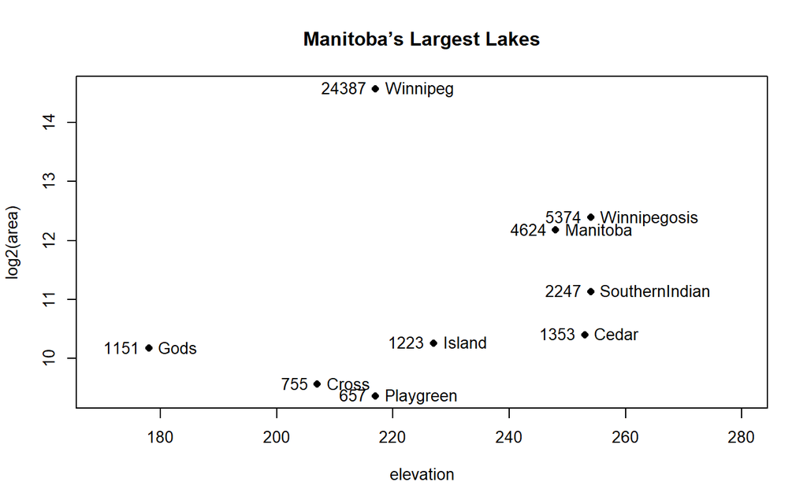

```r
attach(Manitoba.lakes)
plot(log2(area) ~ elevation, pch=16, xlim=c(170,280))

# NB: Doubling the area increases log2(area) by 1.0
text(log2(area) ~ elevation,labels=row.names(Manitoba.lakes), pos=4)
text(log2(area) ~ elevation, labels=area, pos=2)
title("Manitoba’s Largest Lakes")
```

```r
detach(Manitoba.lakes)
```

Devise captions that explain the labeling on the points and on the y-axis. It will be necessary to explain how distances on the scale relate to changes in area!

2. Repeat the plot and associated labeling, now plotting area versus elevation, but specifying log=“y” in order to obtain a logarithmic y-scale. [Note: The log=“y” setting carries across to the subsequent text() commands. See Subsection 2.1.5 for an example.]

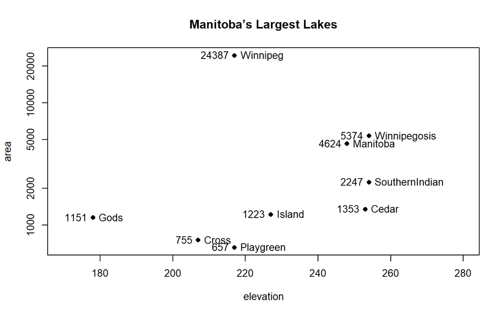

```r
attach(Manitoba.lakes)
plot(area ~ elevation, pch=16, xlim=c(170,280), log="y")

text(area ~ elevation,labels=row.names(Manitoba.lakes), pos=4)
text(area ~ elevation, labels=area, pos=2)
title("Manitoba’s Largest Lakes")
```

```r
detach(Manitoba.lakes)
```

Here, y-axis is plotted in a logarithmic scale.